# Regressao Carseats

## SVM

Par ao SVM vamos usar o modelo Polinomial através do Tidymodel, ajustando o ‘custo’ para atingir o melhor erro quadrático médio.

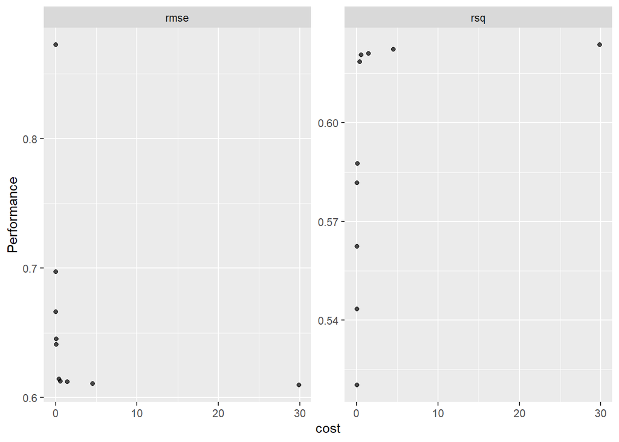

```r
#definição do modelo
svm <- svm_poly( cost = tune()) %>%
        set_args(kernel = "vanilladot") %>%
        set_mode("regression") %>%
        set_engine("kernlab")


##computando diferentes parametros do custo
grid_svm <- tune_grid(svm,
                     receita,
                     resamples = cv_split,
                     grid = 10)
#visao grafica do resultado
autoplot(grid_svm)
```

```r
grid_svm%>%
  collect_metrics()
```

```
## # A tibble: 20 x 6
##        cost .metric .estimator  mean     n std_err
##       <dbl> <chr>   <chr>      <dbl> <int>   <dbl>
##  1  0.00123 rmse    standard   0.872    10  0.0436
##  2  0.00123 rsq     standard   0.520    10  0.0265
##  3  0.00623 rmse    standard   0.697    10  0.0409
##  4  0.00623 rsq     standard   0.543    10  0.0267
##  5  0.0153  rmse    standard   0.666    10  0.0383
##  6  0.0153  rsq     standard   0.562    10  0.0253
##  7  0.0485  rmse    standard   0.645    10  0.0348
##  8  0.0485  rsq     standard   0.582    10  0.0240
##  9  0.0630  rmse    standard   0.641    10  0.0341
## 10  0.0630  rsq     standard   0.588    10  0.0233
## 11  0.381   rmse    standard   0.614    10  0.0293
## 12  0.381   rsq     standard   0.618    10  0.0205
## 13  0.564   rmse    standard   0.612    10  0.0291
## 14  0.564   rsq     standard   0.621    10  0.0201
## 15  1.42    rmse    standard   0.612    10  0.0287
## 16  1.42    rsq     standard   0.621    10  0.0200
## 17  4.53    rmse    standard   0.611    10  0.0285
## 18  4.53    rsq     standard   0.622    10  0.0197
## 19 29.9     rmse    standard   0.610    10  0.0285
## 20 29.9     rsq     standard   0.624    10  0.0201
```

```r
#selecao do melhor hiperparametro
best <- grid_svm %>%
          select_best(metric = "rmse")
best
```

```
## # A tibble: 1 x 1
##    cost
##   <dbl>
## 1  29.9
```

achamos o custo para minimizar o erro quadratico médio.

```r
#finalizando o modelo
svm_fit <- finalize_model(svm, parameters = best)

#ajustando o modelo
svm_fit <- fit(svm_fit,
               Advertising ~ .,
               data = tr_process)
#juntando os dois modelos para avaliação
fitted <- bind_rows(fitted,
                    svm_fit %>%
                     predict(new_data = ts_process) %>%
                     mutate(observado = ts_process$Advertising,
                             modelo = "svm - linear"))



x = svm_fit %>%
            predict(new_data = ts_process) %>%
              mutate(observado = ts_process$Advertising)
rmse(x, truth = observado, estimate = .pred)
```

```
## # A tibble: 1 x 3
##   .metric .estimator .estimate
##   <chr>   <chr>          <dbl>
## 1 rmse    standard       0.697
```

com o SVM vemos um resultado muito similar da Random Forest com um erro quadrático médio também elevado.

# Avaliação

comparação do desemepenho dos dois modelos: Random Forest e SVM

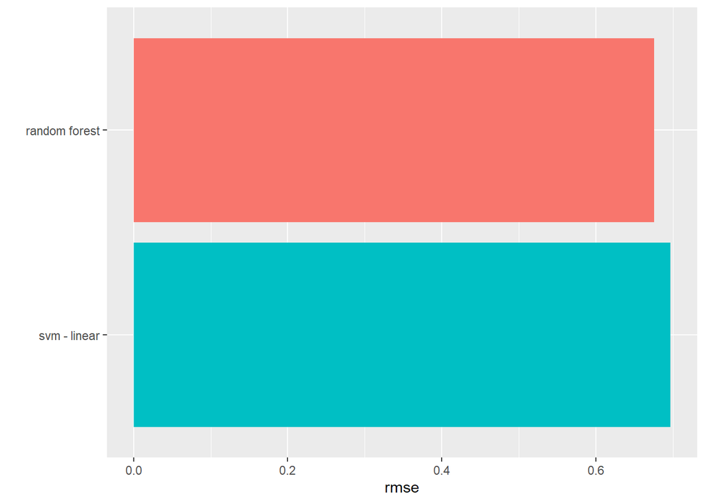

```r
fitted %>%
  group_by(modelo) %>%
  rmse(truth = observado, estimate = .pred) %>%
  ggplot(aes(reorder(modelo, -.estimate), .estimate, fill = modelo )) +
    geom_col(show.legend = FALSE) +
    labs(x = "", y = "rmse") +
    coord_flip()
```

Na comparação vemos que os dois modelos apresentam resultados muito semelhante, sendo praticamente permutáveis na prediçao da variável Advertisment.